# ANCOVA test for leitura (engajamento no leitura)

Geiser C. Challco geiser@alumni.usp.br

- Descriptive Statistics of Initial Data
- Checking of Assumptions
  - Assumption: Normality distribution of data
  - Assumption: Homogeneity of data distribution
- Computation of ANCOVA test and Pairwise Comparison
  - ANCOVA tests for one factor
  - ANCOVA tests for two factors
  - ANCOVA tests for grupo=“stari+WG”
  - Pairwise comparisons for one factor
    - factor: **grupo**
    - factor: **genero**
    - factor: **idade**
    - factor: **zona.participante**
    - factor: **escola**
    - factor: **zona.escola**
  - Pairwise comparisons for two factors
    - factores: **grupo:genero**
    - factores: **grupo:idade**
    - factores: **grupo:zona.participante**
    - factores: **grupo:escola**
    - factores: **grupo:zona.escola**
  - Pairwise comparisons for grupo=“Experimental”
    - factores: **grupo=“Experimental”:monitor**
    - factores: **grupo=“Experimental”:monitor.genero**
    - factores: **grupo=“Experimental”:monitor.area**
    - factores: **grupo=“Experimental”:monitor.formacao**
    - factores: **grupo=“Experimental”:monitor.experiencia**

**NOTE**

- Teste ANCOVA para determinar se houve diferenças significativas em referência ao engajamento no leitura (medido como estado de fluxo).
- ANCOVA test to determine whether there were significant differences in reference to engagement in leitura (measured as flow state).

# Descriptive Statistics of Initial Data

| grupo | genero | idade | zona.participante | escola | zona.escola | variable | n | mean | median | min | max | sd | se | ci | iqr |
| --- | --- | --- | --- | --- | --- | --- | --- | --- | --- | --- | --- | --- | --- | --- | --- |
| Controle | F |  |  |  |  | fss.leitura | 6 | 3.500 | 3.722 | 2.667 | 3.889 | 0.501 | 0.204 | 0.525 | 0.611 |
| Controle | M |  |  |  |  | fss.leitura | 10 | 3.090 | 3.000 | 2.444 | 3.889 | 0.373 | 0.118 | 0.267 | 0.122 |
| stari+WG | F |  |  |  |  | fss.leitura | 4 | 3.361 | 3.333 | 2.778 | 4.000 | 0.675 | 0.338 | 1.074 | 1.139 |
| stari+WG | M |  |  |  |  | fss.leitura | 12 | 3.478 | 3.500 | 2.667 | 4.375 | 0.537 | 0.155 | 0.341 | 0.833 |
| Controle | F |  |  |  |  | dfs.leitura | 6 | 3.241 | 3.056 | 3.000 | 3.778 | 0.340 | 0.139 | 0.357 | 0.444 |
| Controle | M |  |  |  |  | dfs.leitura | 10 | 3.122 | 3.167 | 2.222 | 3.889 | 0.570 | 0.180 | 0.408 | 0.750 |
| stari+WG | F |  |  |  |  | dfs.leitura | 4 | 2.972 | 2.944 | 2.333 | 3.667 | 0.591 | 0.295 | 0.940 | 0.750 |
| stari+WG | M |  |  |  |  | dfs.leitura | 12 | 3.351 | 3.222 | 2.778 | 4.111 | 0.479 | 0.138 | 0.305 | 0.750 |
| Controle |  | 10y |  |  |  | fss.leitura | 4 | 3.500 | 3.722 | 2.667 | 3.889 | 0.563 | 0.281 | 0.896 | 0.389 |
| Controle |  | 11y |  |  |  | fss.leitura | 8 | 3.293 | 3.118 | 2.889 | 3.889 | 0.402 | 0.142 | 0.336 | 0.556 |
| Controle |  | 12y |  |  |  | fss.leitura | 2 | 3.000 | 3.000 | 3.000 | 3.000 | 0.000 | 0.000 | 0.000 | 0.000 |
| Controle |  | 13y |  |  |  | fss.leitura | 1 | 3.111 | 3.111 | 3.111 | 3.111 |  |  |  | 0.000 |
| Controle |  | 15y |  |  |  | fss.leitura | 1 | 2.444 | 2.444 | 2.444 | 2.444 |  |  |  | 0.000 |
| stari+WG |  | 10y |  |  |  | fss.leitura | 2 | 3.944 | 3.944 | 3.889 | 4.000 | 0.079 | 0.056 | 0.706 | 0.056 |
| stari+WG |  | 11y |  |  |  | fss.leitura | 9 | 3.213 | 3.111 | 2.667 | 4.000 | 0.520 | 0.173 | 0.399 | 0.889 |
| stari+WG |  | 12y |  |  |  | fss.leitura | 2 | 3.833 | 3.833 | 3.667 | 4.000 | 0.236 | 0.167 | 2.118 | 0.167 |
| stari+WG |  | 13y |  |  |  | fss.leitura | 3 | 3.569 | 3.333 | 3.000 | 4.375 | 0.717 | 0.414 | 1.782 | 0.688 |
| Controle |  | 10y |  |  |  | dfs.leitura | 4 | 3.361 | 3.333 | 3.000 | 3.778 | 0.367 | 0.184 | 0.584 | 0.528 |
| Controle |  | 11y |  |  |  | dfs.leitura | 8 | 3.181 | 3.167 | 2.222 | 3.889 | 0.518 | 0.183 | 0.433 | 0.583 |
| Controle |  | 12y |  |  |  | dfs.leitura | 2 | 3.222 | 3.222 | 2.778 | 3.667 | 0.629 | 0.444 | 5.647 | 0.444 |
| Controle |  | 13y |  |  |  | dfs.leitura | 1 | 3.000 | 3.000 | 3.000 | 3.000 |  |  |  | 0.000 |
| Controle |  | 15y |  |  |  | dfs.leitura | 1 | 2.333 | 2.333 | 2.333 | 2.333 |  |  |  | 0.000 |
| stari+WG |  | 10y |  |  |  | dfs.leitura | 2 | 2.993 | 2.993 | 2.875 | 3.111 | 0.167 | 0.118 | 1.500 | 0.118 |
| stari+WG |  | 11y |  |  |  | dfs.leitura | 9 | 3.148 | 3.222 | 2.333 | 4.111 | 0.524 | 0.175 | 0.403 | 0.333 |
| stari+WG |  | 12y |  |  |  | dfs.leitura | 2 | 3.500 | 3.500 | 3.333 | 3.667 | 0.236 | 0.167 | 2.118 | 0.167 |
| stari+WG |  | 13y |  |  |  | dfs.leitura | 3 | 3.593 | 3.889 | 2.778 | 4.111 | 0.714 | 0.412 | 1.775 | 0.667 |
| Controle |  |  | Urbana |  |  | fss.leitura | 10 | 3.233 | 3.056 | 2.444 | 3.889 | 0.530 | 0.168 | 0.379 | 0.833 |
| Controle |  |  | Rural |  |  | fss.leitura | 2 | 3.056 | 3.056 | 3.000 | 3.111 | 0.079 | 0.056 | 0.706 | 0.056 |
| Controle |  |  |  |  |  | fss.leitura | 4 | 3.365 | 3.285 | 3.000 | 3.889 | 0.396 | 0.198 | 0.631 | 0.462 |
| stari+WG |  |  | Urbana |  |  | fss.leitura | 6 | 3.600 | 3.833 | 2.778 | 4.375 | 0.675 | 0.276 | 0.708 | 1.000 |
| stari+WG |  |  | Rural |  |  | fss.leitura | 5 | 3.361 | 3.250 | 2.667 | 3.889 | 0.528 | 0.236 | 0.655 | 0.778 |
| stari+WG |  |  |  |  |  | fss.leitura | 5 | 3.356 | 3.333 | 2.778 | 4.000 | 0.493 | 0.221 | 0.612 | 0.667 |
| Controle |  |  | Urbana |  |  | dfs.leitura | 10 | 3.078 | 3.056 | 2.222 | 3.667 | 0.491 | 0.155 | 0.352 | 0.500 |
| Controle |  |  | Rural |  |  | dfs.leitura | 2 | 2.944 | 2.944 | 2.889 | 3.000 | 0.079 | 0.056 | 0.706 | 0.056 |
| Controle |  |  |  |  |  | dfs.leitura | 4 | 3.500 | 3.667 | 2.778 | 3.889 | 0.501 | 0.251 | 0.797 | 0.444 |
| stari+WG |  |  | Urbana |  |  | dfs.leitura | 6 | 3.500 | 3.444 | 2.889 | 4.111 | 0.465 | 0.190 | 0.488 | 0.611 |
| stari+WG |  |  | Rural |  |  | dfs.leitura | 5 | 3.086 | 3.000 | 2.667 | 3.667 | 0.382 | 0.171 | 0.474 | 0.347 |
| stari+WG |  |  |  |  |  | dfs.leitura | 5 | 3.133 | 3.111 | 2.333 | 4.111 | 0.664 | 0.297 | 0.824 | 0.556 |
| Controle |  |  |  | E1 |  | fss.leitura | 6 | 3.111 | 3.056 | 2.444 | 3.778 | 0.531 | 0.217 | 0.557 | 0.778 |
| Controle |  |  |  | E2 |  | fss.leitura | 1 | 3.000 | 3.000 | 3.000 | 3.000 |  |  |  | 0.000 |
| Controle |  |  |  | E4 |  | fss.leitura | 1 | 3.000 | 3.000 | 3.000 | 3.000 |  |  |  | 0.000 |
| Controle |  |  |  | E5 |  | fss.leitura | 6 | 3.317 | 3.118 | 2.889 | 3.889 | 0.451 | 0.184 | 0.473 | 0.670 |
| Controle |  |  |  | E6 |  | fss.leitura | 2 | 3.667 | 3.667 | 3.444 | 3.889 | 0.314 | 0.222 | 2.824 | 0.222 |
| stari+WG |  |  |  | E2 |  | fss.leitura | 2 | 3.000 | 3.000 | 2.667 | 3.333 | 0.471 | 0.333 | 4.235 | 0.333 |
| stari+WG |  |  |  | E4 |  | fss.leitura | 5 | 3.808 | 3.889 | 3.111 | 4.375 | 0.467 | 0.209 | 0.579 | 0.333 |
| stari+WG |  |  |  | E5 |  | fss.leitura | 7 | 3.210 | 3.000 | 2.778 | 4.000 | 0.531 | 0.201 | 0.491 | 0.792 |
| stari+WG |  |  |  | E6 |  | fss.leitura | 2 | 3.833 | 3.833 | 3.667 | 4.000 | 0.236 | 0.167 | 2.118 | 0.167 |
| Controle |  |  |  | E1 |  | dfs.leitura | 6 | 2.963 | 3.056 | 2.222 | 3.556 | 0.578 | 0.236 | 0.607 | 0.944 |
| Controle |  |  |  | E2 |  | dfs.leitura | 1 | 2.778 | 2.778 | 2.778 | 2.778 |  |  |  | 0.000 |
| Controle |  |  |  | E4 |  | dfs.leitura | 1 | 3.667 | 3.667 | 3.667 | 3.667 |  |  |  | 0.000 |
| Controle |  |  |  | E5 |  | dfs.leitura | 6 | 3.130 | 3.000 | 2.889 | 3.556 | 0.257 | 0.105 | 0.270 | 0.250 |
| Controle |  |  |  | E6 |  | dfs.leitura | 2 | 3.833 | 3.833 | 3.778 | 3.889 | 0.079 | 0.056 | 0.706 | 0.056 |
| stari+WG |  |  |  | E2 |  | dfs.leitura | 2 | 3.556 | 3.556 | 3.000 | 4.111 | 0.786 | 0.556 | 7.059 | 0.556 |
| stari+WG |  |  |  | E4 |  | dfs.leitura | 5 | 3.553 | 3.667 | 2.875 | 4.111 | 0.502 | 0.224 | 0.623 | 0.667 |
| stari+WG |  |  |  | E5 |  | dfs.leitura | 7 | 2.968 | 2.889 | 2.333 | 3.667 | 0.438 | 0.166 | 0.406 | 0.500 |
| stari+WG |  |  |  | E6 |  | dfs.leitura | 2 | 3.222 | 3.222 | 3.111 | 3.333 | 0.157 | 0.111 | 1.412 | 0.111 |
| Controle |  |  |  |  | Urbana | fss.leitura | 13 | 3.198 | 3.111 | 2.444 | 3.889 | 0.465 | 0.129 | 0.281 | 0.667 |
| Controle |  |  |  |  | Rural | fss.leitura | 3 | 3.444 | 3.444 | 3.000 | 3.889 | 0.444 | 0.257 | 1.104 | 0.444 |
| stari+WG |  |  |  |  | Urbana | fss.leitura | 9 | 3.164 | 3.000 | 2.667 | 4.000 | 0.498 | 0.166 | 0.383 | 0.556 |
| stari+WG |  |  |  |  | Rural | fss.leitura | 7 | 3.815 | 3.889 | 3.111 | 4.375 | 0.393 | 0.149 | 0.364 | 0.333 |
| Controle |  |  |  |  | Urbana | dfs.leitura | 13 | 3.026 | 3.000 | 2.222 | 3.556 | 0.423 | 0.117 | 0.256 | 0.444 |
| Controle |  |  |  |  | Rural | dfs.leitura | 3 | 3.778 | 3.778 | 3.667 | 3.889 | 0.111 | 0.064 | 0.276 | 0.111 |
| stari+WG |  |  |  |  | Urbana | dfs.leitura | 9 | 3.099 | 3.000 | 2.333 | 4.111 | 0.537 | 0.179 | 0.413 | 0.444 |
| stari+WG |  |  |  |  | Rural | dfs.leitura | 7 | 3.458 | 3.333 | 2.875 | 4.111 | 0.445 | 0.168 | 0.411 | 0.611 |

# Checking of Assumptions

## Assumption: Normality distribution of data

| var | n | skewness | kurtosis | symmetry | statistic | method | p | p.signif | normality |
| --- | --- | --- | --- | --- | --- | --- | --- | --- | --- |
| fss.leitura | 32 | 0.1424513 | -1.0546870 | YES | 0.9688507 | Shapiro-Wilk | 0.4682949 | ns | YES |
| fss.leitura | 32 | 0.4649625 | -0.6013680 | YES | 0.9606767 | Shapiro-Wilk | 0.2866120 | ns | YES |
| fss.leitura | 23 | 0.0819067 | -1.5610723 | YES | 0.9071624 | Shapiro-Wilk | 0.0356097 | * | NO |
| fss.leitura | 32 | 0.2721634 | -0.8708968 | YES | 0.9704799 | Shapiro-Wilk | 0.5127524 | ns | YES |
| fss.leitura | 32 | 0.3840549 | -0.7900089 | YES | 0.9585594 | Shapiro-Wilk | 0.2507329 | ns | YES |

## Assumption: Homogeneity of data distribution

| var | method | formula | n | DFn.df1 | DFd.df2 | statistic | p | p.signif |
| --- | --- | --- | --- | --- | --- | --- | --- | --- |
| fss.leitura | Levene’s test | `.res`~`grupo`*`genero` | 32 | 3 | 28 | 1.6435094 | 0.2018080 | ns |
| fss.leitura | Anova’s slopes | `.res`~`grupo`*`genero` | 32 | 3 | 24 | 0.2100000 | 0.8880000 | ns |
| fss.leitura | Levene’s test | `.res`~`grupo`*`idade` | 32 | 8 | 23 | 0.5753803 | 0.7873204 | ns |
| fss.leitura | Anova’s slopes | `.res`~`grupo`*`idade` | 32 | 6 | 16 | 0.3380000 | 0.9070000 | ns |
| fss.leitura | Levene’s test | `.res`~`grupo`*`zona.participante` | 23 | 3 | 19 | 1.3615440 | 0.2846382 | ns |
| fss.leitura | Anova’s slopes | `.res`~`grupo`*`zona.participante` | 23 | 3 | 15 | 2.0170000 | 0.1550000 | ns |
| fss.leitura | Levene’s test | `.res`~`grupo`*`escola` | 32 | 8 | 23 | 0.4948332 | 0.8473023 | ns |
| fss.leitura | Anova’s slopes | `.res`~`grupo`*`escola` | 32 | 6 | 16 | 0.4550000 | 0.8310000 | ns |
| fss.leitura | Levene’s test | `.res`~`grupo`*`zona.escola` | 32 | 3 | 28 | 0.0685331 | 0.9762137 | ns |
| fss.leitura | Anova’s slopes | `.res`~`grupo`*`zona.escola` | 32 | 3 | 24 | 0.1900000 | 0.9020000 | ns |

# Computation of ANCOVA test and Pairwise Comparison

## ANCOVA tests for one factor

|  | Effect | DFn | DFd | SSn | SSd | F | p | ges | p<.05 |
| --- | --- | --- | --- | --- | --- | --- | --- | --- | --- |
| 1 | dfs.leitura | 1 | 29 | 1.368 | 6.352 | 6.247 | 0.018 | 0.177 | * |
| 2 | grupo | 1 | 29 | 0.221 | 6.352 | 1.008 | 0.324 | 0.034 |  |
| 4 | genero | 1 | 29 | 0.258 | 6.314 | 1.187 | 0.285 | 0.039 |  |
| 6 | idade | 4 | 26 | 0.913 | 5.660 | 1.048 | 0.402 | 0.139 |  |
| 8 | zona.participante | 1 | 20 | 0.000 | 5.488 | 0.000 | 0.986 | 0.000 |  |
| 10 | escola | 4 | 26 | 1.104 | 5.468 | 1.313 | 0.291 | 0.168 |  |
| 12 | zona.escola | 1 | 29 | 0.800 | 5.772 | 4.021 | 0.054 | 0.122 |  |

## ANCOVA tests for two factors

|  | Effect | DFn | DFd | SSn | SSd | F | p | ges | p<.05 |
| --- | --- | --- | --- | --- | --- | --- | --- | --- | --- |
| 1 | dfs.leitura | 1 | 27 | 1.189 | 5.860 | 5.480 | 0.027 | 0.169 | * |
| 4 | grupo:genero | 1 | 27 | 0.164 | 5.860 | 0.756 | 0.392 | 0.027 |  |
| 8 | grupo:idade | 3 | 22 | 0.781 | 4.613 | 1.242 | 0.318 | 0.145 |  |
| 12 | grupo:zona.participante | 1 | 18 | 0.003 | 5.287 | 0.010 | 0.922 | 0.001 |  |
| 16 | grupo:escola | 3 | 22 | 0.702 | 4.678 | 1.100 | 0.370 | 0.130 |  |
| 20 | grupo:zona.escola | 1 | 27 | 0.410 | 5.301 | 2.089 | 0.160 | 0.072 |  |

## ANCOVA tests for grupo=“stari+WG”

|  | Effect | DFn | DFd | SSn | SSd | F | p | ges | p<.05 |
| --- | --- | --- | --- | --- | --- | --- | --- | --- | --- |
| 1 | dfs.leitura | 1 | 4 | 0.029 | 0.897 | 0.130 | 0.737 | 0.031 |  |
| 2 | monitor | 5 | 4 | 1.544 | 0.897 | 1.377 | 0.390 | 0.632 |  |
| 4 | monitor.genero | 1 | 8 | 0.002 | 2.438 | 0.007 | 0.936 | 0.001 |  |
| 6 | monitor.area | 5 | 4 | 1.544 | 0.897 | 1.377 | 0.390 | 0.632 |  |
| 8 | monitor.formacao | 2 | 7 | 0.328 | 2.113 | 0.543 | 0.604 | 0.134 |  |
| 10 | monitor.experiencia | 1 | 8 | 0.103 | 2.337 | 0.353 | 0.569 | 0.042 |  |

## Pairwise comparisons for one factor

### factor: **grupo**

| var | grupo | n | M (pre) | SE (pre) | M (unadj) | SE (unadj) | M (adj) | SE (adj) |
| --- | --- | --- | --- | --- | --- | --- | --- | --- |
| fss.leitura | Controle | 16 | 3.167 | 0.122 | 3.244 | 0.114 | 3.263 | 0.117 |
| fss.leitura | stari+WG | 16 | 3.256 | 0.129 | 3.449 | 0.138 | 3.430 | 0.117 |

| .y. | group1 | group2 | estimate | conf.low | conf.high | se | statistic | p | p.adj | p.adj.signif |
| --- | --- | --- | --- | --- | --- | --- | --- | --- | --- | --- |
| fss.leitura | Controle | stari+WG | -0.167 | -0.507 | 0.173 | 0.166 | -1.004 | 0.324 | 0.324 | ns |
| dfs.leitura | Controle | stari+WG | -0.089 | -0.452 | 0.273 | 0.177 | -0.504 | 0.618 | 0.618 | ns |

| .y. | grupo | group1 | group2 | estimate | conf.low | conf.high | se | statistic | p | p.adj | p.adj.signif |
| --- | --- | --- | --- | --- | --- | --- | --- | --- | --- | --- | --- |
| flow.leitura | Controle | pre | pos | -0.077 | -0.434 | 0.280 | 0.178 | -0.433 | 0.667 | 0.667 | ns |
| flow.leitura | stari+WG | pre | pos | -0.193 | -0.550 | 0.164 | 0.178 | -1.080 | 0.284 | 0.284 | ns |

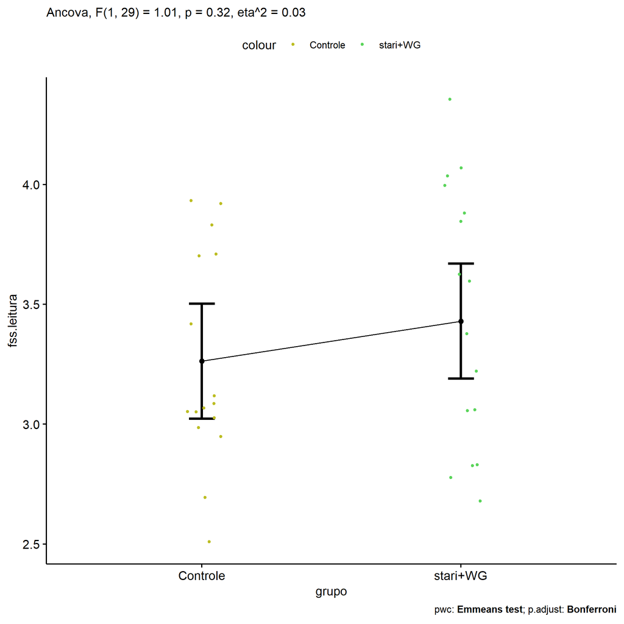

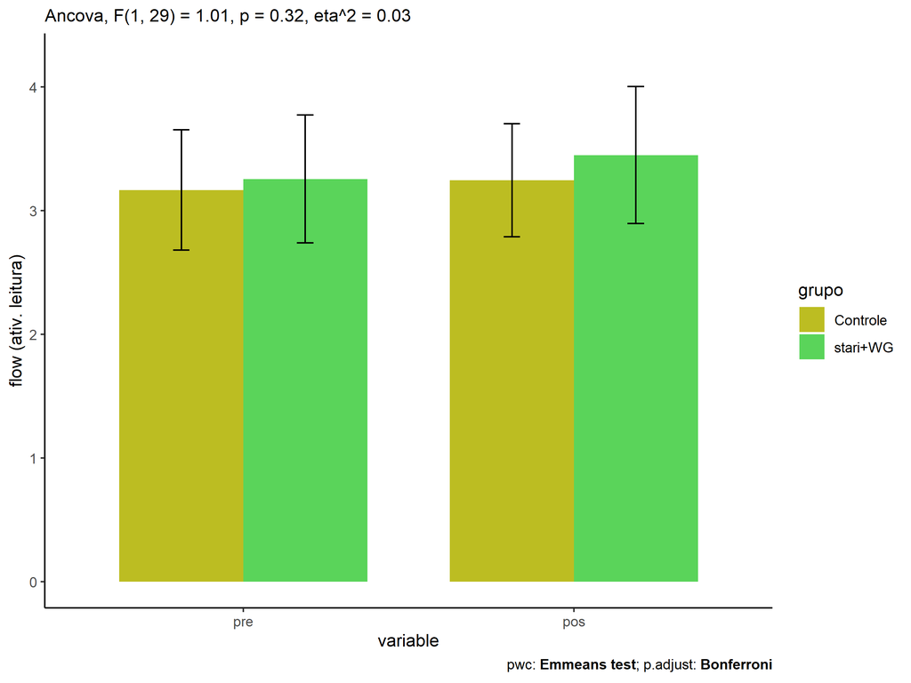

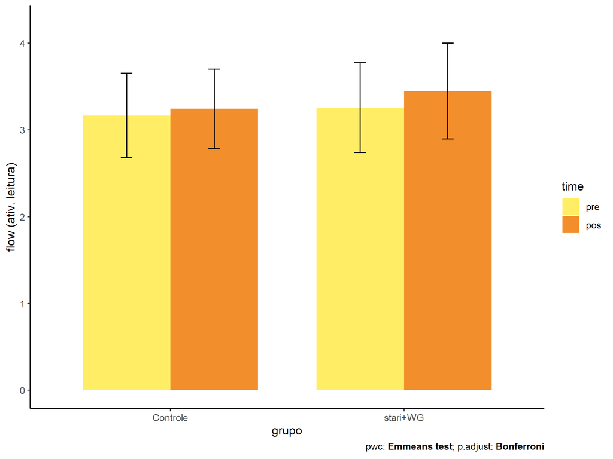

### factor: **genero**

| var | genero | n | M (pre) | SE (pre) | M (unadj) | SE (unadj) | M (adj) | SE (adj) |
| --- | --- | --- | --- | --- | --- | --- | --- | --- |
| fss.leitura | F | 10 | 3.133 | 0.141 | 3.444 | 0.172 | 3.480 | 0.148 |
| fss.leitura | M | 22 | 3.247 | 0.111 | 3.302 | 0.107 | 3.285 | 0.100 |

| .y. | group1 | group2 | estimate | conf.low | conf.high | se | statistic | p | p.adj | p.adj.signif |
| --- | --- | --- | --- | --- | --- | --- | --- | --- | --- | --- |
| fss.leitura | F | M | 0.195 | -0.171 | 0.561 | 0.179 | 1.089 | 0.285 | 0.285 | ns |
| dfs.leitura | F | M | -0.114 | -0.504 | 0.277 | 0.191 | -0.594 | 0.557 | 0.557 | ns |

| .y. | genero | group1 | group2 | estimate | conf.low | conf.high | se | statistic | p | p.adj | p.adj.signif |
| --- | --- | --- | --- | --- | --- | --- | --- | --- | --- | --- | --- |
| flow.leitura | F | pre | pos | -0.311 | -0.765 | 0.143 | 0.227 | -1.371 | 0.176 | 0.176 | ns |
| flow.leitura | M | pre | pos | -0.055 | -0.361 | 0.251 | 0.153 | -0.359 | 0.721 | 0.721 | ns |

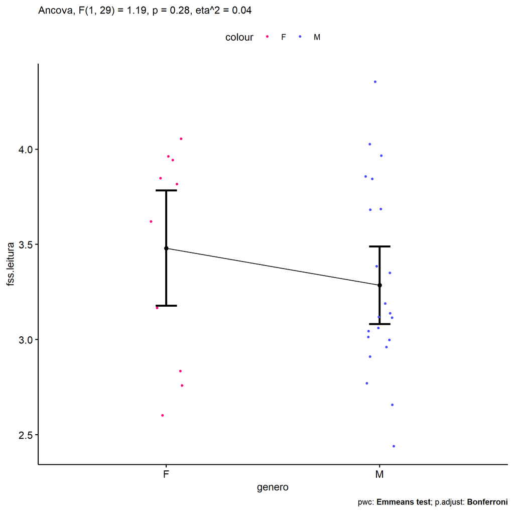

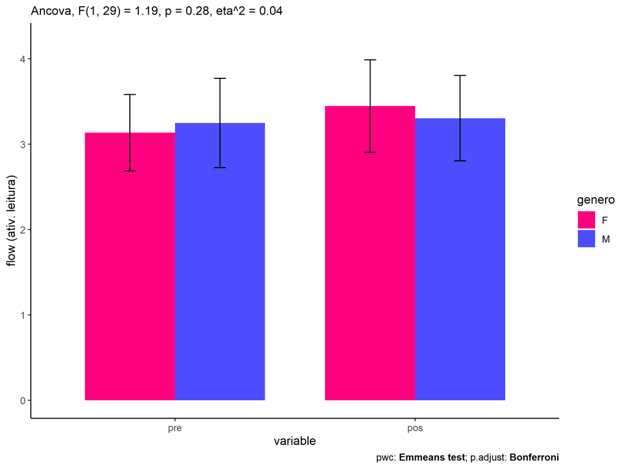

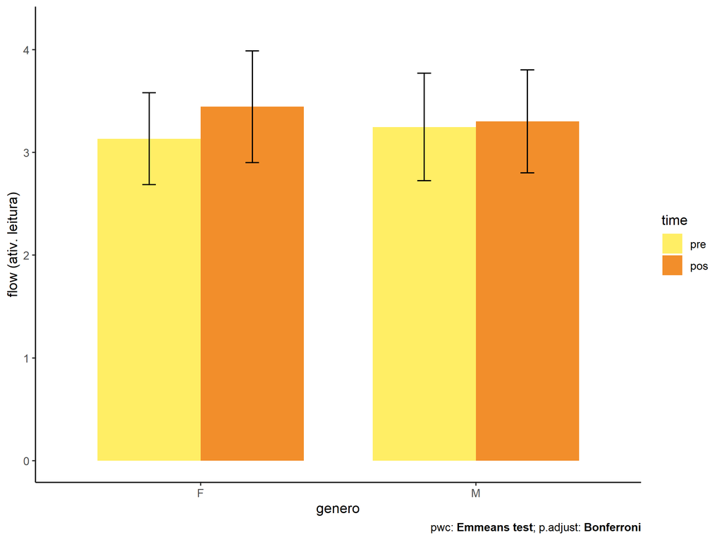

### factor: **idade**

| var | idade | n | M (pre) | SE (pre) | M (unadj) | SE (unadj) | M (adj) | SE (adj) |
| --- | --- | --- | --- | --- | --- | --- | --- | --- |
| fss.leitura | 10y | 6 | 3.238 | 0.143 | 3.648 | 0.202 | 3.634 | 0.188 |
| fss.leitura | 11y | 17 | 3.163 | 0.122 | 3.251 | 0.110 | 3.256 | 0.111 |

| .y. | group1 | group2 | estimate | conf.low | conf.high | se | statistic | p | p.adj | p.adj.signif |
| --- | --- | --- | --- | --- | --- | --- | --- | --- | --- | --- |
| fss.leitura | 10y | 11y | 0.378 | -0.078 | 0.834 | 0.219 | 1.728 | 0.099 | 0.099 | ns |
| dfs.leitura | 10y | 11y | 0.075 | -0.392 | 0.542 | 0.224 | 0.334 | 0.741 | 0.741 | ns |

| .y. | idade | group1 | group2 | estimate | conf.low | conf.high | se | statistic | p | p.adj | p.adj.signif |
| --- | --- | --- | --- | --- | --- | --- | --- | --- | --- | --- | --- |
| flow.leitura | 10y | pre | pos | -0.410 | -0.956 | 0.136 | 0.271 | -1.514 | 0.138 | 0.138 | ns |
| flow.leitura | 11y | pre | pos | -0.087 | -0.412 | 0.237 | 0.161 | -0.544 | 0.589 | 0.589 | ns |

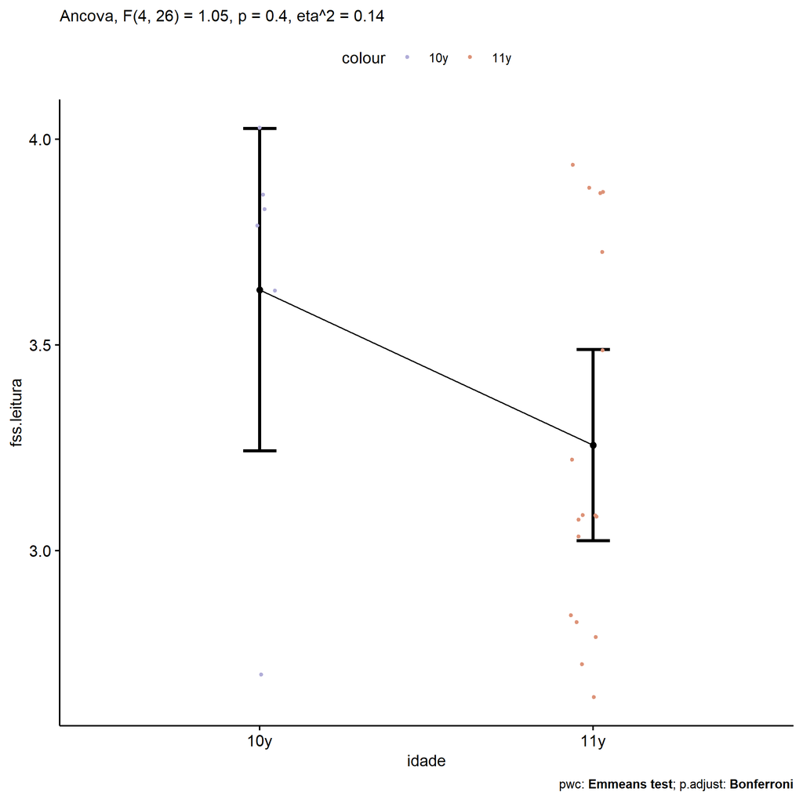

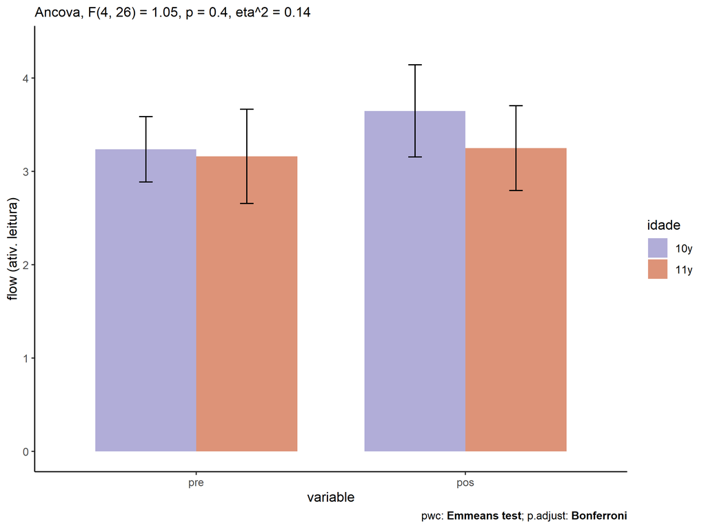

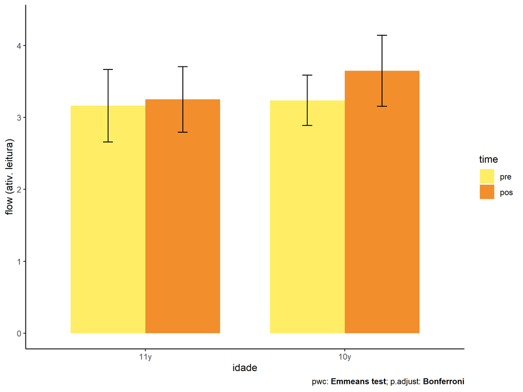

### factor: **zona.participante**

| var | zona.participante | n | M (pre) | SE (pre) | M (unadj) | SE (unadj) | M (adj) | SE (adj) |
| --- | --- | --- | --- | --- | --- | --- | --- | --- |
| fss.leitura | Rural | 7 | 3.046 | 0.121 | 3.274 | 0.173 | 3.338 | 0.201 |
| fss.leitura | Urbana | 16 | 3.236 | 0.128 | 3.371 | 0.149 | 3.342 | 0.132 |

| .y. | group1 | group2 | estimate | conf.low | conf.high | se | statistic | p | p.adj | p.adj.signif |
| --- | --- | --- | --- | --- | --- | --- | --- | --- | --- | --- |
| fss.leitura | Urbana | Rural | 0.004 | -0.501 | 0.509 | 0.242 | 0.017 | 0.986 | 0.986 | ns |
| dfs.leitura | Urbana | Rural | 0.190 | -0.248 | 0.629 | 0.211 | 0.904 | 0.376 | 0.376 | ns |

| .y. | zona.participante | group1 | group2 | estimate | conf.low | conf.high | se | statistic | p | p.adj | p.adj.signif |
| --- | --- | --- | --- | --- | --- | --- | --- | --- | --- | --- | --- |
| flow.leitura | Urbana | pre | pos | -0.135 | -0.501 | 0.232 | 0.182 | -0.74 | 0.463 | 0.463 | ns |
| flow.leitura | Rural | pre | pos | -0.228 | -0.783 | 0.326 | 0.275 | -0.83 | 0.411 | 0.411 | ns |

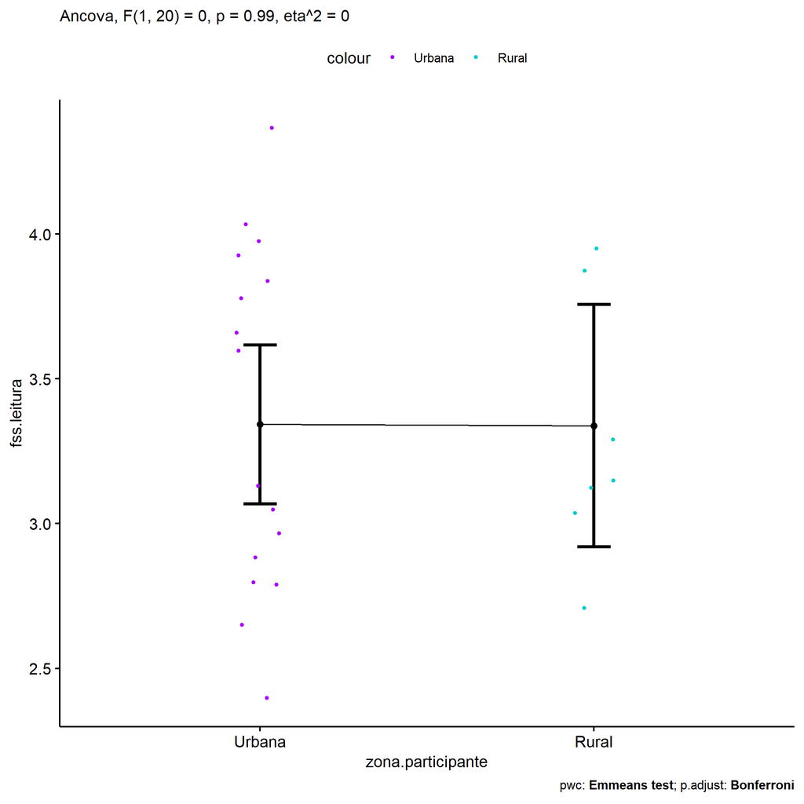

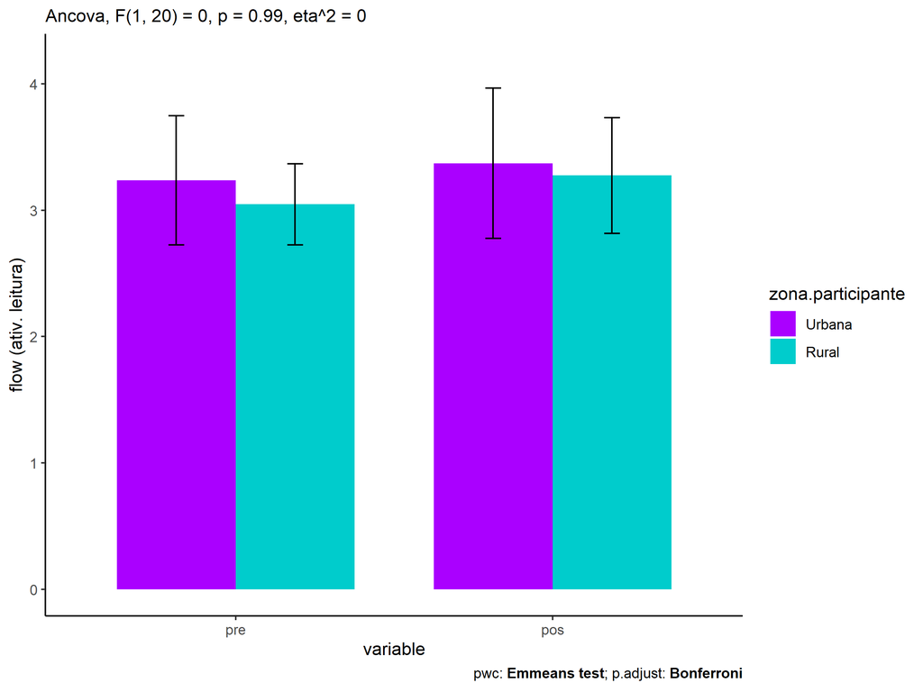

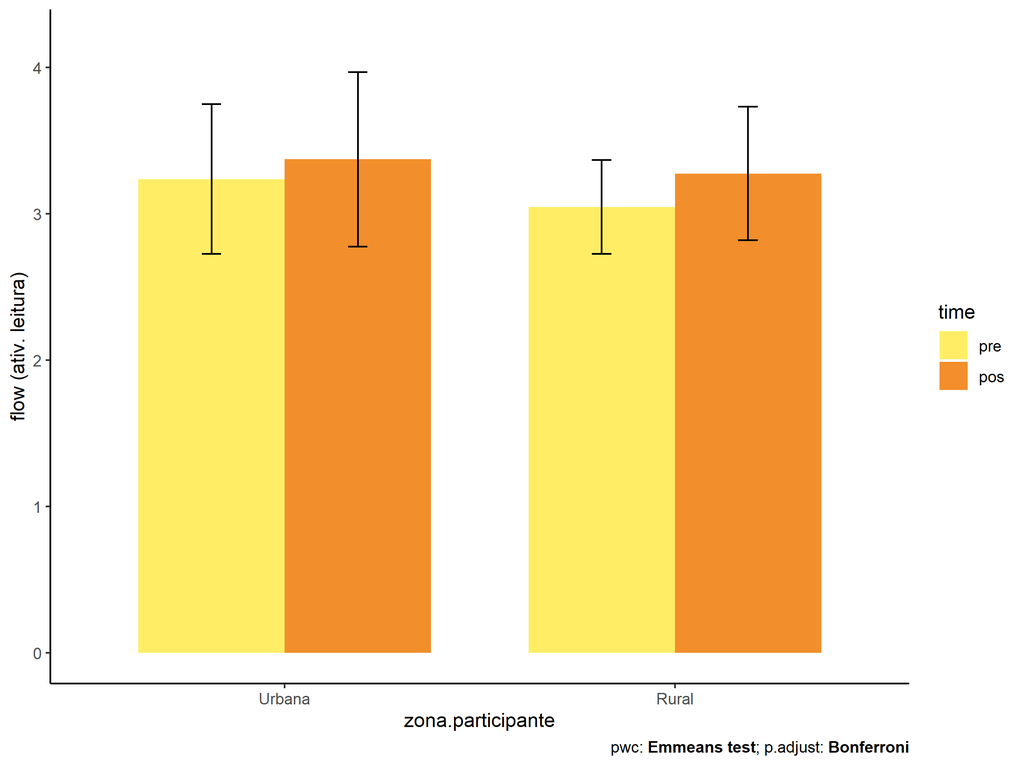

### factor: **escola**

| var | escola | n | M (pre) | SE (pre) | M (unadj) | SE (unadj) | M (adj) | SE (adj) |
| --- | --- | --- | --- | --- | --- | --- | --- | --- |
| fss.leitura | E1 | 6 | 2.963 | 0.236 | 3.111 | 0.217 | 3.177 | 0.205 |
| fss.leitura | E4 | 6 | 3.572 | 0.184 | 3.674 | 0.217 | 3.527 | 0.224 |
| fss.leitura | E5 | 13 | 3.043 | 0.100 | 3.260 | 0.133 | 3.297 | 0.138 |

| .y. | group1 | group2 | estimate | conf.low | conf.high | se | statistic | p | p.adj | p.adj.signif |
| --- | --- | --- | --- | --- | --- | --- | --- | --- | --- | --- |
| fss.leitura | E1 | E4 | -0.350 | -1.011 | 0.311 | 0.318 | -1.101 | 0.283 | 0.850 | ns |
| fss.leitura | E1 | E5 | -0.121 | -0.626 | 0.384 | 0.243 | -0.497 | 0.624 | 1.000 | ns |
| fss.leitura | E4 | E5 | 0.229 | -0.338 | 0.797 | 0.273 | 0.841 | 0.410 | 1.000 | ns |
| dfs.leitura | E1 | E4 | -0.609 | -1.135 | -0.082 | 0.254 | -2.397 | 0.025 | 0.076 | ns |
| dfs.leitura | E1 | E5 | -0.080 | -0.530 | 0.370 | 0.217 | -0.367 | 0.717 | 1.000 | ns |
| dfs.leitura | E4 | E5 | 0.529 | 0.079 | 0.979 | 0.217 | 2.437 | 0.023 | 0.070 | ns |

| .y. | escola | group1 | group2 | estimate | conf.low | conf.high | se | statistic | p | p.adj | p.adj.signif |
| --- | --- | --- | --- | --- | --- | --- | --- | --- | --- | --- | --- |
| flow.leitura | E1 | pre | pos | -0.148 | -0.698 | 0.402 | 0.273 | -0.543 | 0.590 | 0.590 | ns |
| flow.leitura | E4 | pre | pos | -0.102 | -0.652 | 0.448 | 0.273 | -0.373 | 0.711 | 0.711 | ns |
| flow.leitura | E5 | pre | pos | -0.217 | -0.590 | 0.157 | 0.185 | -1.170 | 0.248 | 0.248 | ns |

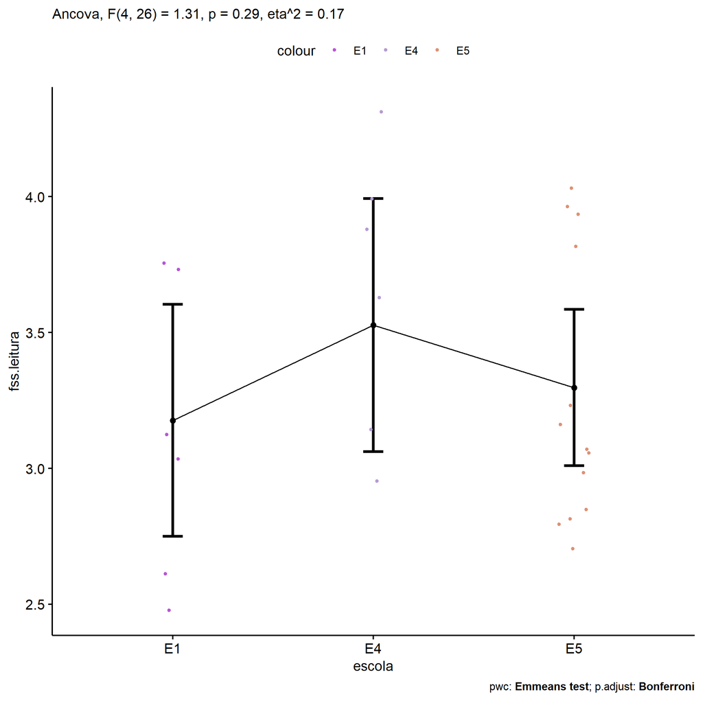

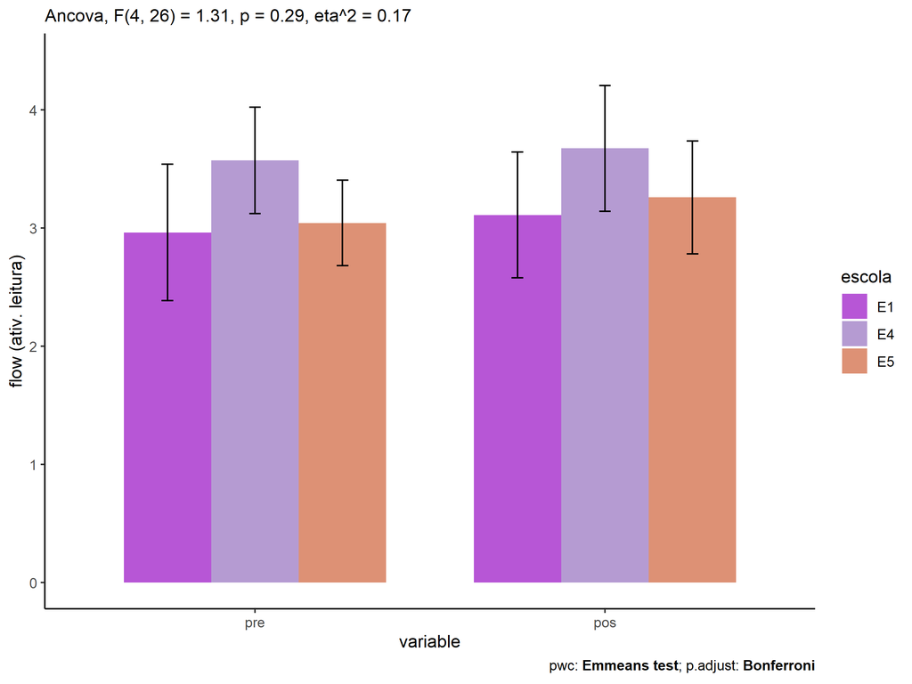

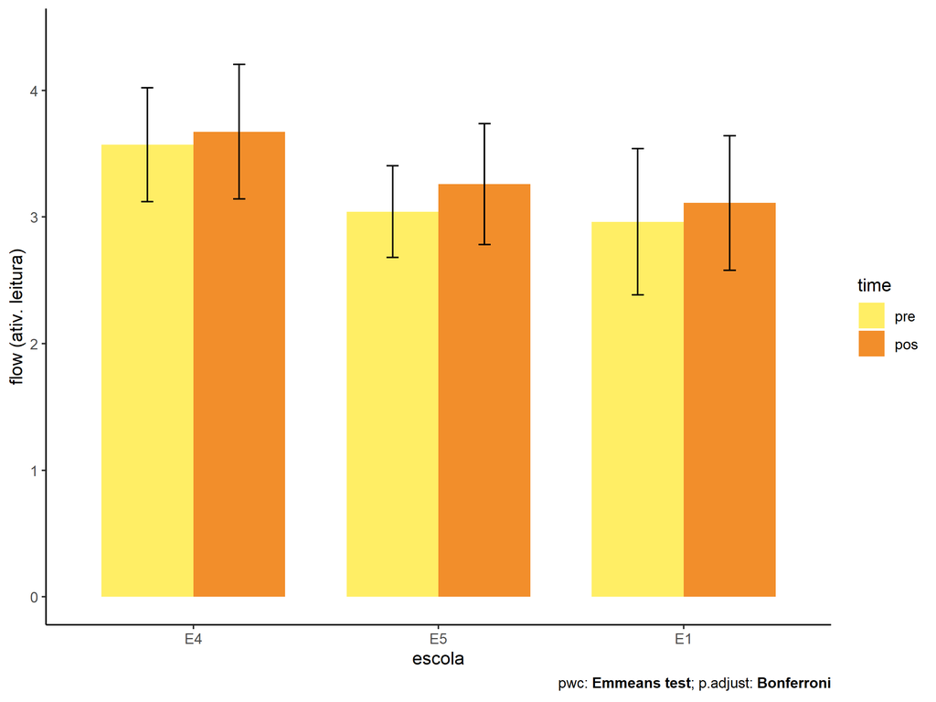

### factor: **zona.escola**

| var | zona.escola | n | M (pre) | SE (pre) | M (unadj) | SE (unadj) | M (adj) | SE (adj) |
| --- | --- | --- | --- | --- | --- | --- | --- | --- |
| fss.leitura | Rural | 10 | 3.554 | 0.126 | 3.704 | 0.134 | 3.613 | 0.154 |
| fss.leitura | Urbana | 22 | 3.056 | 0.099 | 3.184 | 0.100 | 3.225 | 0.099 |

| .y. | group1 | group2 | estimate | conf.low | conf.high | se | statistic | p | p.adj | p.adj.signif |
| --- | --- | --- | --- | --- | --- | --- | --- | --- | --- | --- |
| fss.leitura | Urbana | Rural | -0.387 | -0.782 | 0.008 | 0.193 | -2.005 | 0.054 | 0.054 | ns |
| dfs.leitura | Urbana | Rural | -0.499 | -0.844 | -0.153 | 0.169 | -2.945 | 0.006 | 0.006 | ** |

| .y. | zona.escola | group1 | group2 | estimate | conf.low | conf.high | se | statistic | p | p.adj | p.adj.signif |
| --- | --- | --- | --- | --- | --- | --- | --- | --- | --- | --- | --- |
| flow.leitura | Urbana | pre | pos | -0.128 | -0.399 | 0.143 | 0.135 | -0.946 | 0.348 | 0.348 | ns |
| flow.leitura | Rural | pre | pos | -0.150 | -0.552 | 0.252 | 0.201 | -0.747 | 0.458 | 0.458 | ns |

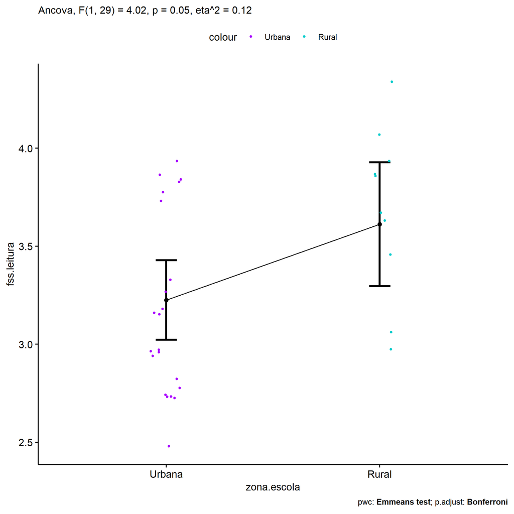

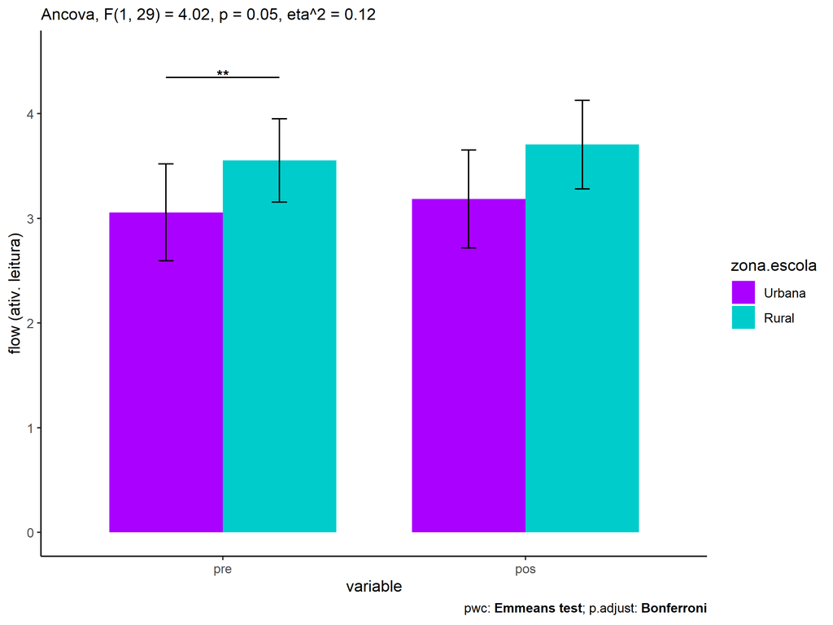

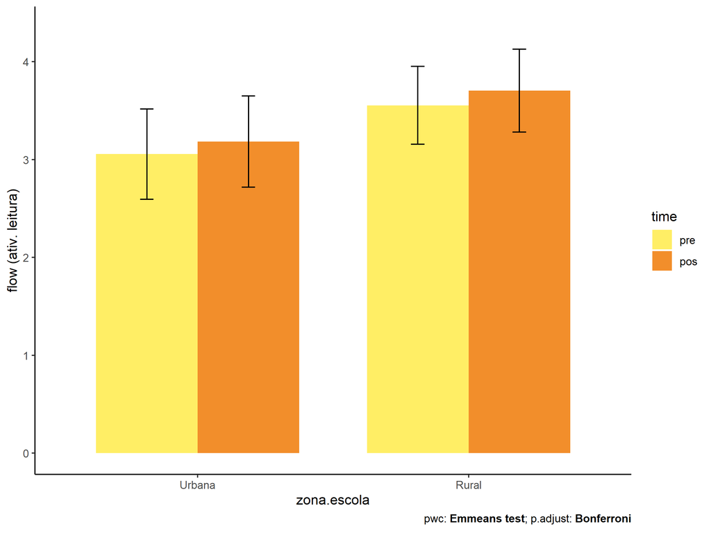

## Pairwise comparisons for two factors

### factores: **grupo:genero**

| var | grupo | genero | n | M (pre) | SE (pre) | M (unadj) | SE (unadj) | M (adj) | SE (adj) |
| --- | --- | --- | --- | --- | --- | --- | --- | --- | --- |
| fss.leitura | Controle | F | 6 | 3.241 | 0.139 | 3.500 | 0.204 | 3.502 | 0.181 |
| fss.leitura | Controle | M | 10 | 3.122 | 0.180 | 3.090 | 0.118 | 3.139 | 0.142 |
| fss.leitura | stari+WG | M | 12 | 3.351 | 0.138 | 3.478 | 0.155 | 3.436 | 0.130 |

|  | .y. | grupo | genero | group1 | group2 | estimate | conf.low | conf.high | se | statistic | p | p.adj | p.adj.signif |
| --- | --- | --- | --- | --- | --- | --- | --- | --- | --- | --- | --- | --- | --- |
| 2 | fss.leitura |  | M | Controle | stari+WG | -0.297 | -0.699 | 0.105 | 0.195 | -1.527 | 0.140 | 0.140 | ns |
| 4 | dfs.leitura |  | M | Controle | stari+WG | -0.228 | -0.662 | 0.205 | 0.210 | -1.086 | 0.288 | 0.288 | ns |
| 5 | fss.leitura | Controle |  | F | M | 0.363 | -0.113 | 0.838 | 0.230 | 1.575 | 0.128 | 0.128 | ns |
| 7 | dfs.leitura | Controle |  | F | M | 0.119 | -0.404 | 0.641 | 0.254 | 0.467 | 0.644 | 0.644 | ns |

| .y. | grupo | genero | group1 | group2 | estimate | conf.low | conf.high | se | statistic | p | p.adj | p.adj.signif |
| --- | --- | --- | --- | --- | --- | --- | --- | --- | --- | --- | --- | --- |
| flow.leitura | Controle | F | pre | pos | -0.259 | -0.821 | 0.302 | 0.279 | -0.928 | 0.358 | 0.358 | ns |
| flow.leitura | Controle | M | pre | pos | 0.032 | -0.403 | 0.467 | 0.216 | 0.148 | 0.883 | 0.883 | ns |
| flow.leitura | stari+WG | M | pre | pos | -0.127 | -0.524 | 0.270 | 0.198 | -0.644 | 0.522 | 0.522 | ns |

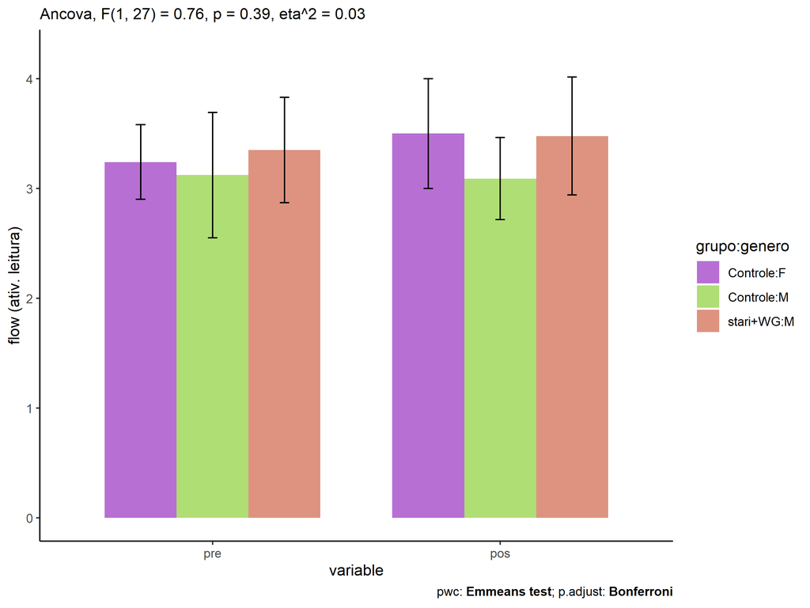

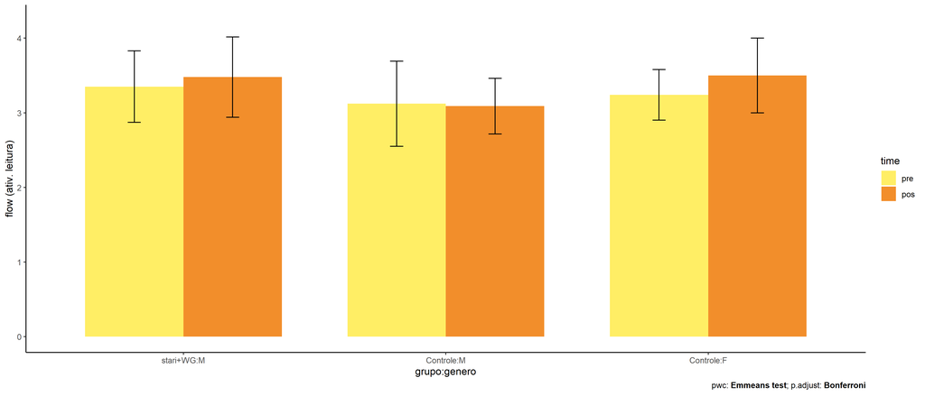

### factores: **grupo:idade**

### factores: **grupo:zona.participante**

| var | grupo | zona.participante | n | M (pre) | SE (pre) | M (unadj) | SE (unadj) | M (adj) | SE (adj) |
| --- | --- | --- | --- | --- | --- | --- | --- | --- | --- |
| fss.leitura | Controle | Urbana | 10 | 3.078 | 0.155 | 3.233 | 0.168 | 3.283 | 0.180 |
| fss.leitura | stari+WG | Rural | 5 | 3.086 | 0.171 | 3.361 | 0.236 | 3.408 | 0.251 |
| fss.leitura | stari+WG | Urbana | 6 | 3.500 | 0.190 | 3.600 | 0.276 | 3.478 | 0.243 |

|  | .y. | grupo | zona.participante | group1 | group2 | estimate | conf.low | conf.high | se | statistic | p | p.adj | p.adj.signif |
| --- | --- | --- | --- | --- | --- | --- | --- | --- | --- | --- | --- | --- | --- |
| 1 | fss.leitura |  | Urbana | Controle | stari+WG | -0.194 | -0.853 | 0.464 | 0.312 | -0.623 | 0.542 | 0.542 | ns |
| 3 | dfs.leitura |  | Urbana | Controle | stari+WG | -0.422 | -0.923 | 0.079 | 0.238 | -1.771 | 0.094 | 0.094 | ns |
| 6 | fss.leitura | stari+WG |  | Urbana | Rural | 0.070 | -0.684 | 0.824 | 0.358 | 0.196 | 0.847 | 0.847 | ns |
| 8 | dfs.leitura | stari+WG |  | Urbana | Rural | 0.414 | -0.174 | 1.001 | 0.280 | 1.480 | 0.156 | 0.156 | ns |

| .y. | grupo | zona.participante | group1 | group2 | estimate | conf.low | conf.high | se | statistic | p | p.adj | p.adj.signif |
| --- | --- | --- | --- | --- | --- | --- | --- | --- | --- | --- | --- | --- |
| flow.leitura | Controle | Urbana | pre | pos | -0.156 | -0.628 | 0.317 | 0.233 | -0.668 | 0.508 | 0.508 | ns |
| flow.leitura | stari+WG | Urbana | pre | pos | -0.100 | -0.709 | 0.510 | 0.301 | -0.331 | 0.742 | 0.742 | ns |
| flow.leitura | stari+WG | Rural | pre | pos | -0.275 | -0.943 | 0.393 | 0.329 | -0.835 | 0.409 | 0.409 | ns |

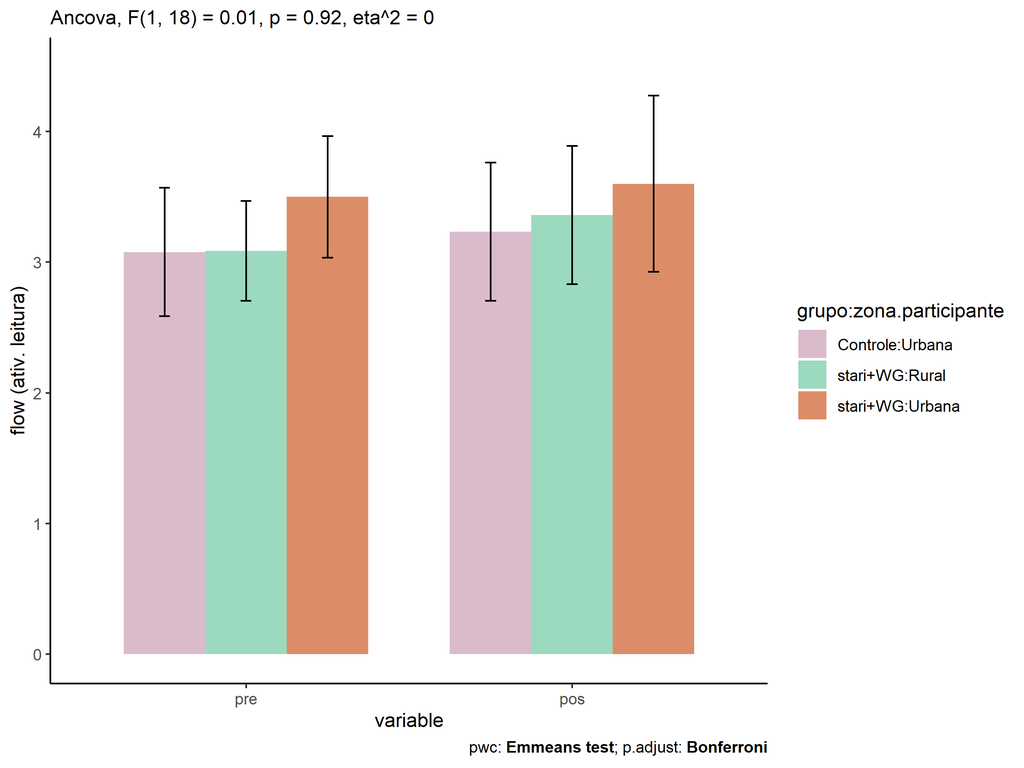

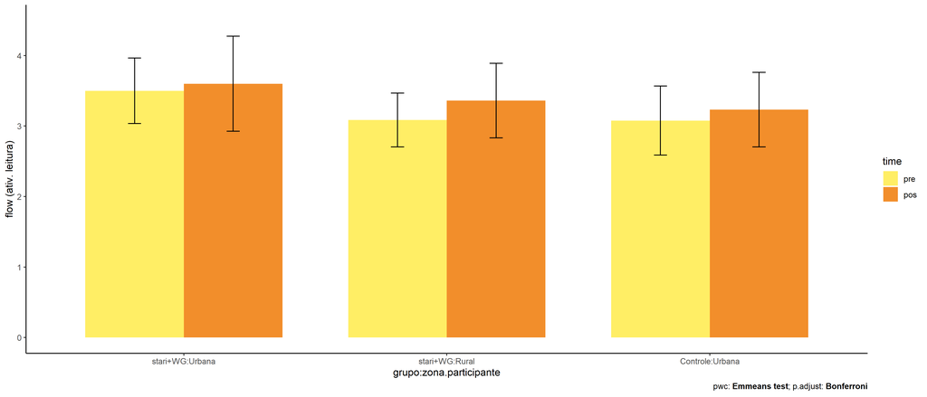

### factores: **grupo:escola**

| var | grupo | escola | n | M (pre) | SE (pre) | M (unadj) | SE (unadj) | M (adj) | SE (adj) |
| --- | --- | --- | --- | --- | --- | --- | --- | --- | --- |
| fss.leitura | Controle | E1 | 6 | 2.963 | 0.236 | 3.111 | 0.217 | 3.171 | 0.201 |
| fss.leitura | Controle | E5 | 6 | 3.130 | 0.105 | 3.317 | 0.184 | 3.317 | 0.197 |
| fss.leitura | stari+WG | E4 | 5 | 3.553 | 0.224 | 3.808 | 0.209 | 3.655 | 0.238 |
| fss.leitura | stari+WG | E5 | 7 | 2.968 | 0.166 | 3.210 | 0.201 | 3.268 | 0.187 |

|  | .y. | grupo | escola | group1 | group2 | estimate | conf.low | conf.high | se | statistic | p | p.adj | p.adj.signif |
| --- | --- | --- | --- | --- | --- | --- | --- | --- | --- | --- | --- | --- | --- |
| 3 | fss.leitura |  | E5 | Controle | stari+WG | 0.048 | -0.520 | 0.617 | 0.272 | 0.178 | 0.860 | 0.860 | ns |
| 6 | dfs.leitura |  | E5 | Controle | stari+WG | 0.161 | -0.368 | 0.691 | 0.254 | 0.636 | 0.532 | 0.532 | ns |
| 8 | fss.leitura | Controle |  | E1 | E5 | -0.146 | -0.736 | 0.444 | 0.282 | -0.517 | 0.611 | 0.611 | ns |
| 12 | fss.leitura | stari+WG |  | E4 | E5 | 0.387 | -0.273 | 1.046 | 0.315 | 1.226 | 0.235 | 0.235 | ns |
| 14 | dfs.leitura | Controle |  | E1 | E5 | -0.167 | -0.716 | 0.383 | 0.263 | -0.633 | 0.534 | 0.534 | ns |
| 18 | dfs.leitura | stari+WG |  | E4 | E5 | 0.585 | 0.027 | 1.142 | 0.267 | 2.188 | 0.041 | 0.041 | * |

| .y. | grupo | escola | group1 | group2 | estimate | conf.low | conf.high | se | statistic | p | p.adj | p.adj.signif |
| --- | --- | --- | --- | --- | --- | --- | --- | --- | --- | --- | --- | --- |
| flow.leitura | Controle | E1 | pre | pos | -0.148 | -0.706 | 0.410 | 0.276 | -0.537 | 0.595 | 0.595 | ns |
| flow.leitura | Controle | E5 | pre | pos | -0.188 | -0.746 | 0.371 | 0.276 | -0.679 | 0.501 | 0.501 | ns |
| flow.leitura | stari+WG | E4 | pre | pos | -0.256 | -0.867 | 0.356 | 0.302 | -0.845 | 0.403 | 0.403 | ns |
| flow.leitura | stari+WG | E5 | pre | pos | -0.242 | -0.759 | 0.275 | 0.256 | -0.947 | 0.349 | 0.349 | ns |

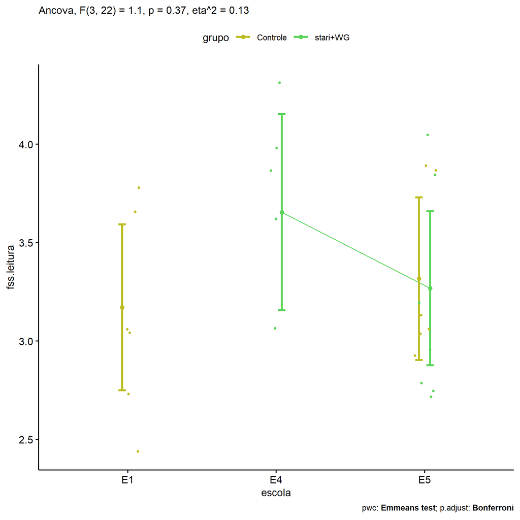

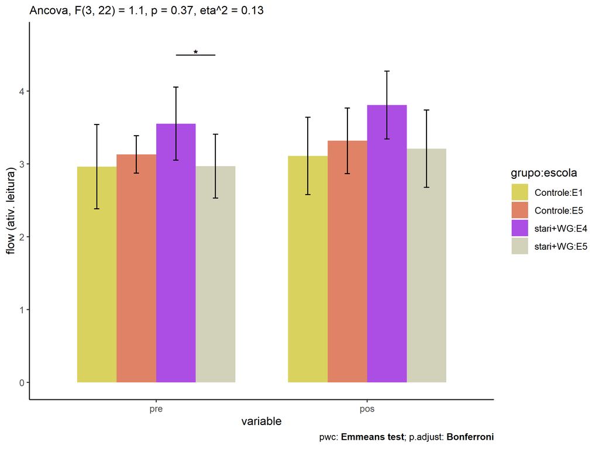

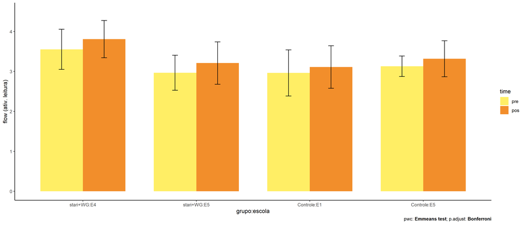

### factores: **grupo:zona.escola**

| var | grupo | zona.escola | n | M (pre) | SE (pre) | M (unadj) | SE (unadj) | M (adj) | SE (adj) |
| --- | --- | --- | --- | --- | --- | --- | --- | --- | --- |
| fss.leitura | Controle | Urbana | 13 | 3.026 | 0.117 | 3.198 | 0.129 | 3.238 | 0.125 |
| fss.leitura | stari+WG | Rural | 7 | 3.458 | 0.168 | 3.815 | 0.149 | 3.719 | 0.177 |
| fss.leitura | stari+WG | Urbana | 9 | 3.099 | 0.179 | 3.164 | 0.166 | 3.181 | 0.148 |

|  | .y. | grupo | zona.escola | group1 | group2 | estimate | conf.low | conf.high | se | statistic | p | p.adj | p.adj.signif |
| --- | --- | --- | --- | --- | --- | --- | --- | --- | --- | --- | --- | --- | --- |
| 1 | fss.leitura |  | Urbana | Controle | stari+WG | 0.057 | -0.341 | 0.455 | 0.193 | 0.296 | 0.769 | 0.769 | ns |
| 3 | dfs.leitura |  | Urbana | Controle | stari+WG | -0.073 | -0.488 | 0.342 | 0.202 | -0.362 | 0.720 | 0.720 | ns |
| 6 | fss.leitura | stari+WG |  | Urbana | Rural | -0.538 | -1.019 | -0.056 | 0.234 | -2.301 | 0.030 | 0.030 | * |
| 8 | dfs.leitura | stari+WG |  | Urbana | Rural | -0.360 | -0.842 | 0.123 | 0.235 | -1.531 | 0.138 | 0.138 | ns |

| .y. | grupo | zona.escola | group1 | group2 | estimate | conf.low | conf.high | se | statistic | p | p.adj | p.adj.signif |
| --- | --- | --- | --- | --- | --- | --- | --- | --- | --- | --- | --- | --- |
| flow.leitura | Controle | Urbana | pre | pos | -0.172 | -0.536 | 0.192 | 0.182 | -0.947 | 0.348 | 0.348 | ns |
| flow.leitura | stari+WG | Urbana | pre | pos | -0.065 | -0.503 | 0.373 | 0.218 | -0.297 | 0.768 | 0.768 | ns |
| flow.leitura | stari+WG | Rural | pre | pos | -0.357 | -0.854 | 0.140 | 0.248 | -1.443 | 0.155 | 0.155 | ns |

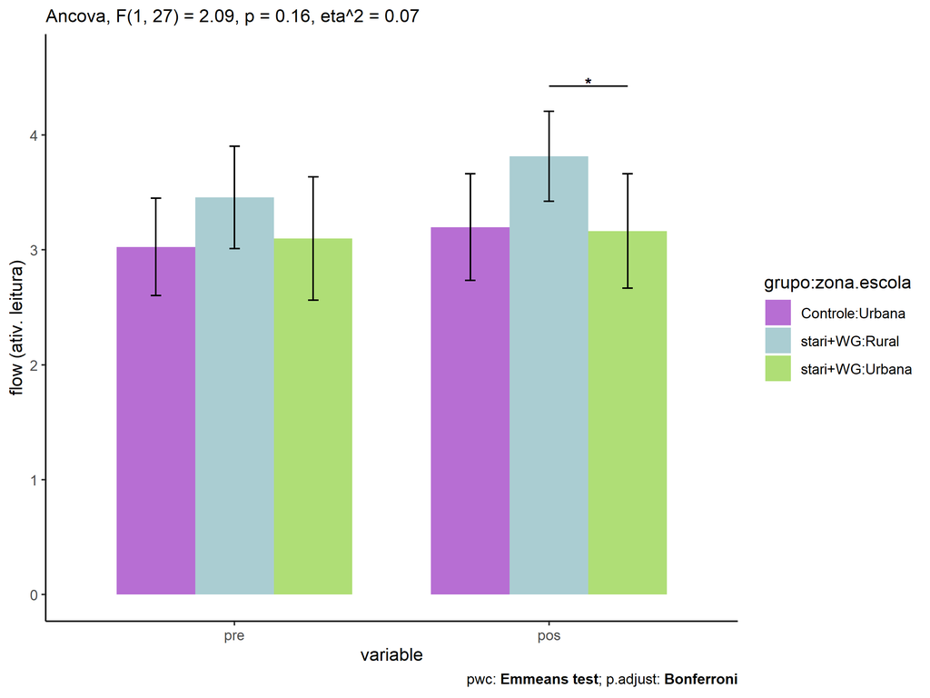

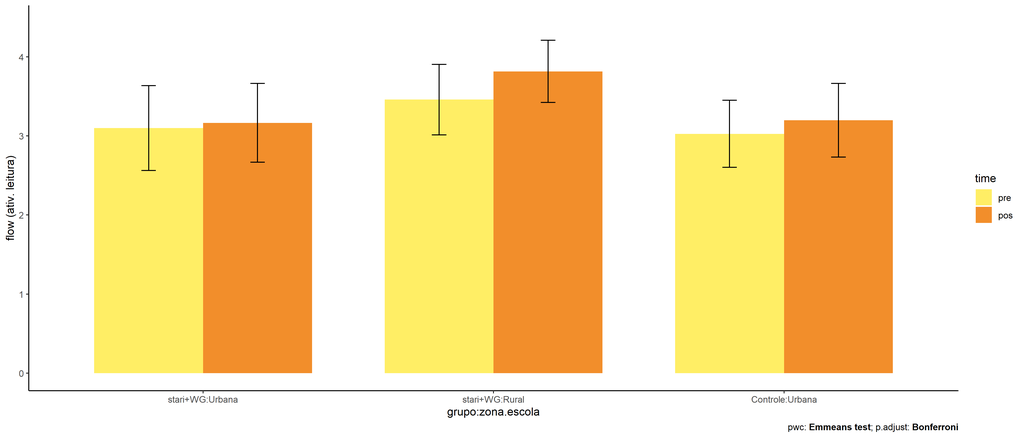

## Pairwise comparisons for grupo=“Experimental”

### factores: **grupo=“Experimental”:monitor**

### factores: **grupo=“Experimental”:monitor.genero**

### factores: **grupo=“Experimental”:monitor.area**

### factores: **grupo=“Experimental”:monitor.formacao**

| var | monitor.formacao | n | M (pre) | SE (pre) | M (unadj) | SE (unadj) | M (adj) | SE (adj) |
| --- | --- | --- | --- | --- | --- | --- | --- | --- |
| fss.leitura | ensino medio | 5 | 3.000 | 0.176 | 3.178 | 0.274 | 3.287 | 0.273 |
| fss.leitura | especializacao | 5 | 3.553 | 0.224 | 3.808 | 0.209 | 3.699 | 0.273 |

| .y. | group1 | group2 | estimate | conf.low | conf.high | se | statistic | p | p.adj | p.adj.signif |
| --- | --- | --- | --- | --- | --- | --- | --- | --- | --- | --- |
| fss.leitura | ensino medio | especializacao | -0.412 | -1.408 | 0.584 | 0.421 | -0.977 | 0.361 | 0.361 | ns |
| dfs.leitura | ensino medio | especializacao | -0.553 | -1.210 | 0.104 | 0.285 | -1.940 | 0.088 | 0.088 | ns |

| .y. | monitor.formacao | group1 | group2 | estimate | conf.low | conf.high | se | statistic | p | p.adj | p.adj.signif |
| --- | --- | --- | --- | --- | --- | --- | --- | --- | --- | --- | --- |
| flow.leitura | ensino medio | pre | pos | -0.178 | -0.847 | 0.492 | 0.316 | -0.563 | 0.581 | 0.581 | ns |
| flow.leitura | especializacao | pre | pos | -0.256 | -0.925 | 0.414 | 0.316 | -0.809 | 0.430 | 0.430 | ns |

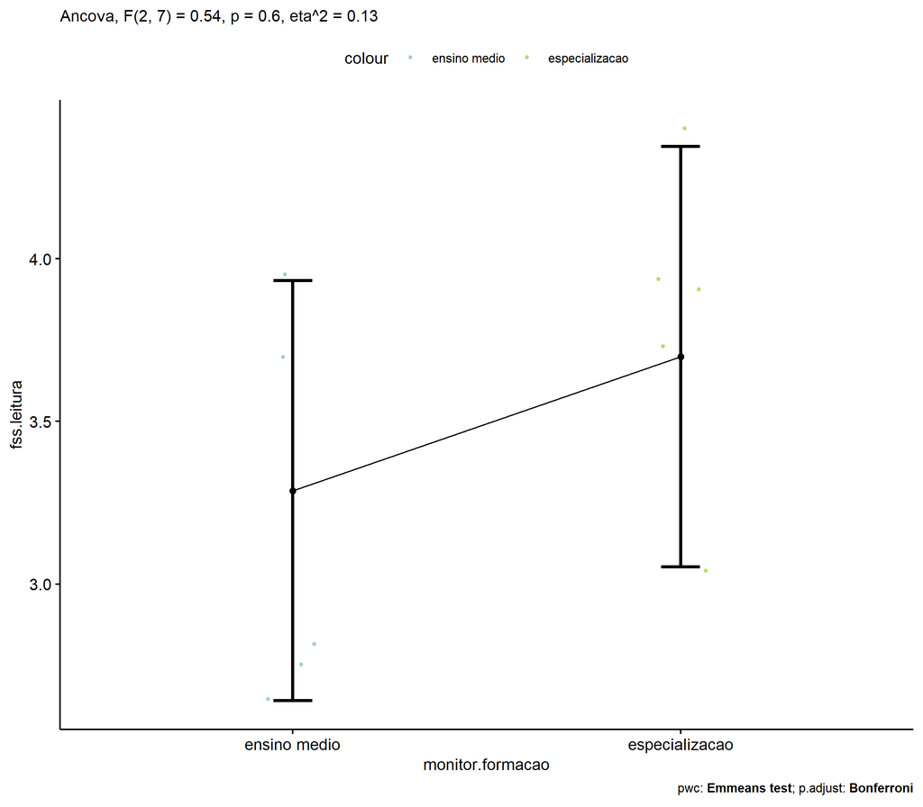

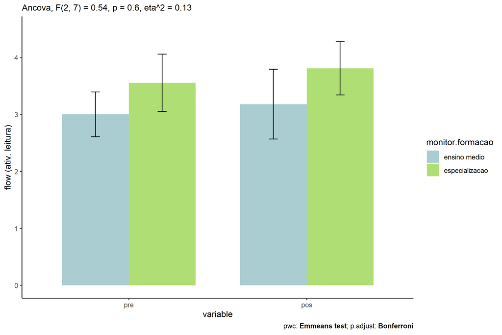

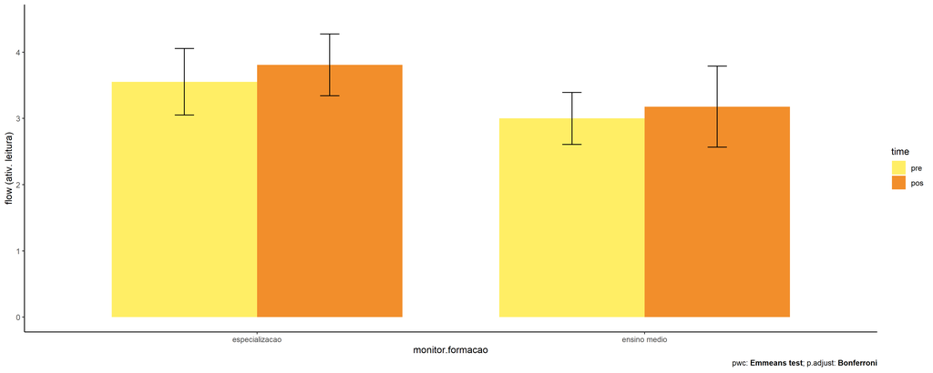

### factores: **grupo=“Experimental”:monitor.experiencia**